# W3cubDocs

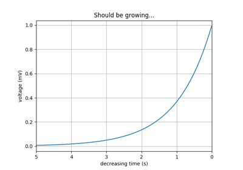

[Invert Axes](https://matplotlib.org/3.1.1/gallery/subplots_axes_and_figures/invert_axes.html#sphx-glr-gallery-subplots-axes-and-figures-invert-axes-py)

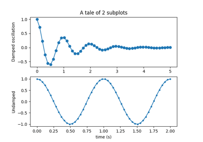

[Multiple subplots](https://matplotlib.org/3.1.1/gallery/subplots_axes_and_figures/subplot.html#sphx-glr-gallery-subplots-axes-and-figures-subplot-py)

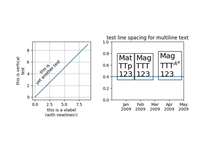

[Multiline](https://matplotlib.org/3.1.1/gallery/text_labels_and_annotations/multiline.html#sphx-glr-gallery-text-labels-and-annotations-multiline-py)

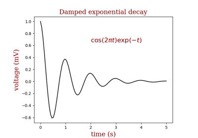

[Controlling style of text and labels using a dictionary](https://matplotlib.org/3.1.1/gallery/text_labels_and_annotations/text_fontdict.html#sphx-glr-gallery-text-labels-and-annotations-text-fontdict-py)

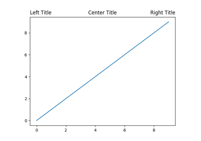

[Titles Demo](https://matplotlib.org/3.1.1/gallery/text_labels_and_annotations/titles_demo.html#sphx-glr-gallery-text-labels-and-annotations-titles-demo-py)

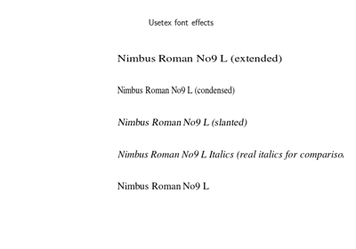

[Usetex Fonteffects](https://matplotlib.org/3.1.1/gallery/text_labels_and_annotations/usetex_fonteffects.html#sphx-glr-gallery-text-labels-and-annotations-usetex-fonteffects-py)

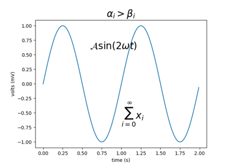

[Pyplot Mathtext](https://matplotlib.org/3.1.1/gallery/pyplots/pyplot_mathtext.html#sphx-glr-gallery-pyplots-pyplot-mathtext-py)

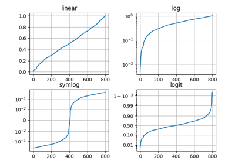

[Pyplot Scales](https://matplotlib.org/3.1.1/gallery/pyplots/pyplot_scales.html#sphx-glr-gallery-pyplots-pyplot-scales-py)

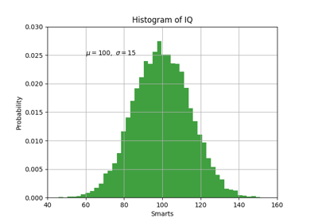

[Pyplot Text](https://matplotlib.org/3.1.1/gallery/pyplots/pyplot_text.html#sphx-glr-gallery-pyplots-pyplot-text-py)

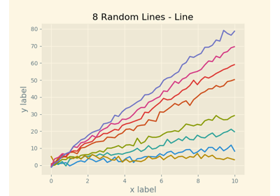

[Solarized Light stylesheet](https://matplotlib.org/3.1.1/gallery/style_sheets/plot_solarizedlight2.html#sphx-glr-gallery-style-sheets-plot-solarizedlight2-py)

[Interactive functions](https://matplotlib.org/3.1.1/gallery/event_handling/ginput_manual_clabel_sgskip.html#sphx-glr-gallery-event-handling-ginput-manual-clabel-sgskip-py)

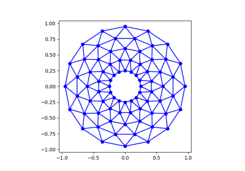

[Trifinder Event Demo](https://matplotlib.org/3.1.1/gallery/event_handling/trifinder_event_demo.html#sphx-glr-gallery-event-handling-trifinder-event-demo-py)

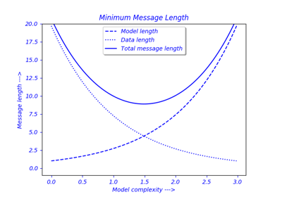

[Findobj Demo](https://matplotlib.org/3.1.1/gallery/misc/findobj_demo.html#sphx-glr-gallery-misc-findobj-demo-py)

[Multipage PDF](https://matplotlib.org/3.1.1/gallery/misc/multipage_pdf.html#sphx-glr-gallery-misc-multipage-pdf-py)

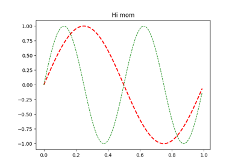

[Set And Get](https://matplotlib.org/3.1.1/gallery/misc/set_and_get.html#sphx-glr-gallery-misc-set-and-get-py)

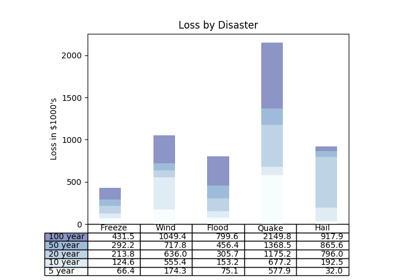

[Table Demo](https://matplotlib.org/3.1.1/gallery/misc/table_demo.html#sphx-glr-gallery-misc-table-demo-py)

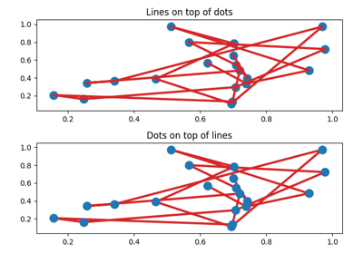

[Zorder Demo](https://matplotlib.org/3.1.1/gallery/misc/zorder_demo.html#sphx-glr-gallery-misc-zorder-demo-py)

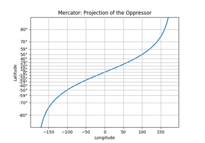

[Custom scale](https://matplotlib.org/3.1.1/gallery/scales/custom_scale.html#sphx-glr-gallery-scales-custom-scale-py)

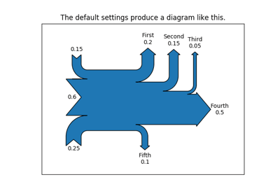

[The Sankey class](https://matplotlib.org/3.1.1/gallery/specialty_plots/sankey_basics.html#sphx-glr-gallery-specialty-plots-sankey-basics-py)

[SVG Histogram](https://matplotlib.org/3.1.1/gallery/user_interfaces/svg_histogram_sgskip.html#sphx-glr-gallery-user-interfaces-svg-histogram-sgskip-py)

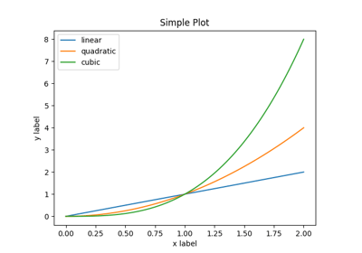

[Usage Guide](https://matplotlib.org/3.1.1/tutorials/introductory/usage.html#sphx-glr-tutorials-introductory-usage-py)

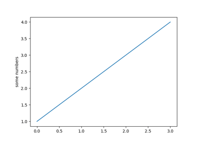

[Pyplot tutorial](https://matplotlib.org/3.1.1/tutorials/introductory/pyplot.html#sphx-glr-tutorials-introductory-pyplot-py)